# Project: Investigate a Dataset - [FBI Gun Data]

- Introduction
- Data Wrangling
- Exploratory Data Analysis
- Conclusions

## Introduction

### Dataset Description

The data comes from the FBI's National Instant Criminal Background Check System[(NICS)](https://www.fbi.gov/file-repository/nics_firearm_checks_-_month_year_by_state_type.pdf/view). The NICS is used to determine whether a prospective buyer is eligible to buy firearms or explosives. Gun shops call into this system to ensure that each custoer does not have a criminal record or isn't otherwise ineliginle to make a purchase. The data has been supplemented with state level data from[census.gov](https://www.census.gov/).

The first table is made up of 27 columns:

1. 'month'
2. 'state'
3. 'permit'
4. 'permit_recheck'
5. 'handgun'
6. 'long_gun'
7. 'other'
8. 'multiple'
9. 'admin'
10. 'prepawn_handgun'
11. 'prepawn_long_gun'
12. 'prepawn_other'
13. 'redemption_handgun'
14. 'redemption_long_gun'
15. 'redemption_other'
16. 'returned_handgun'
17. 'returned_long_gun',
18. 'returned_other'
19. 'rentals_handgun'
20. 'rentals_long_gun',
21. 'private_sale_handgun'
22. 'private_sale_long_gun'
23. 'private_sale_other'
24. 'return_to_seller_handgun'
25. 'return_to_seller_long_gun'
26. 'return_to_seller_other'
27. 'totals'

Each column represents the type of transaction submitted to the NICS. Each type of transaction is broken down by the type of firearm.

- Hand Gun - ) any firearm which has a short stock and is designed to be held and fired by the use of a single hand; and (b) any combination of parts from which a firearm described in paragraph (a) can be assembled
- Long Gun - a weapon designed or redesigned, made or remade to use the energy of the explosive in (a) a fixed metallic catridge to fire a single e projectile through a rifled bore for each single pull of the trigger; or (b) a fixed shotgun shell to fire through a smooth bore either a number of ball shot or a single projectile for each single pull of the trigger.
- Other - refers to frames, receivers, and other firearms that are neither handguns nor long guns (rifles or shotguns), such as firearms having a pistol grip that expel a shotgun shell, or National Firearms Act firearms, including silencers.

Columns 1 and 2 denote the month and location of the transaction

Columns 3 - 9 are for background checks initiated by a officially-licensed Federal Firearms License(FFL) or criminal justice/law enforcement agency prior to the issuance of a firearm-related permit or transfer. The indication of “multiple” denotes a background check where more than one type of firearm is associated to a single background check and “admin” denotes the administrative checks that are for other authorized uses of the NICS.

Other types of transactions are explained below:

- Pre-Pawn—background checks requested by an officially-licensed FFL on prospective firearm transferees seeking to pledge or pawn a firearm as security for the payment or repayment of money, prior to actually pledging or pawning the firearm.
- Redemption—background checks requested by an officially-licensed FFL on prospective firearm transferees attempting to regain possession of a firearm after pledging or pawning a firearm as security at a pawn shop.
- Returned/Disposition—background checks requested by criminal justice/law enforcement agencies prior to returning a firearm in its possession to the respective transferee, to ensure the individual is not prohibited.
- Rentals—background checks requested by an officially-licensed FFL on prospective firearm transferees attempting to possess a firearm when the firearm is loaned or rented for use off the premises of the business.
- Private Sale—background checks requested by an officially-licensed FFL on prospective firearm transferees attempting to possess a firearm from a private party seller who is not an officially-licensed FFL.
- Return to Seller-Private Sale—background checks requested by an officially-licensed FFL on prospective firearm transferees attempting to possess a firearm from a private party seller who is not an officially-licensed FFL.

It is important to note that the statistics within this chart represent the number of firearm background checks initiated through the NICS. They do not represent the number of firearms sold. Based on varying state laws and purchase scenarios, a one-to-one correlation cannot be made between a firearm background check and a firearm sale

A method used to estimate the gun sales was documented by in a [NYT analysis of the same data](https://github.com/nytimes/gunsales#getting-gun-sales-estimates-from-background-checks) and used here

### Question(s) for Analysis

> Q1 What is the overall trend of gun purchases and background checks

> Q2 Which state had the most background checks/ sales

> Q3Which state had the highest growth of gun registrations

> Q4 Which census data is most associated with a high gun per capita

> **Tip**: Once you start coding, use NumPy arrays, Pandas Series, and DataFrames where appropriate rather than Python lists and dictionaries. Also, **use good coding practices**, such as, define and use functions to avoid repetitive code. Use appropriate comments within the code cells, explanation in the mark-down cells, and meaningful variable names.

```python
#Import packages
import pandas as pd
import numpy as np
import matplotlib.pyplot as plt
import seaborn as sns
%matplotlib inline
sns.set_style('darkgrid')
```

## Data Wrangling

```python
#gun data was downloaded as an xlsx file and converted to csv with microsoft excel
df_gun = pd.read_csv('gun_data.csv')
df_census = pd.read_csv('U.S. Census Data.csv')
```

```python
df_gun.head(1)
```

|  | month | state | permit | permit_recheck | handgun | long_gun | other | multiple | admin | prepawn_handgun | ... | returned_other | rentals_handgun | rentals_long_gun | private_sale_handgun | private_sale_long_gun | private_sale_other | return_to_seller_handgun | return_to_seller_long_gun | return_to_seller_other | totals |
| --- | --- | --- | --- | --- | --- | --- | --- | --- | --- | --- | --- | --- | --- | --- | --- | --- | --- | --- | --- | --- | --- |
| 0 | 2017-09 | Alabama | 16717.0 | 0.0 | 5734.0 | 6320.0 | 221.0 | 317 | 0.0 | 15.0 | ... | 0.0 | 0.0 | 0.0 | 9.0 | 16.0 | 3.0 | 0.0 | 0.0 | 3.0 | 32019 |

1 rows × 27 columns

```python
df_gun.shape
```

```
(12485, 27)
```

```python
sum(df_gun.duplicated())
```

```
0
```

```python
df_gun.dtypes
```

```
month                         object
state                         object
permit                       float64
permit_recheck               float64
handgun                      float64
long_gun                     float64
other                        float64
multiple                       int64
admin                        float64
prepawn_handgun              float64
prepawn_long_gun             float64
prepawn_other                float64
redemption_handgun           float64
redemption_long_gun          float64
redemption_other             float64
returned_handgun             float64
returned_long_gun            float64
returned_other               float64
rentals_handgun              float64
rentals_long_gun             float64
private_sale_handgun         float64
private_sale_long_gun        float64
private_sale_other           float64
return_to_seller_handgun     float64
return_to_seller_long_gun    float64
return_to_seller_other       float64
totals                         int64
dtype: object
```

```python
df_gun.info()
```

```
<class 'pandas.core.frame.DataFrame'>
RangeIndex: 12485 entries, 0 to 12484
Data columns (total 27 columns):
 #   Column                     Non-Null Count  Dtype
---  ------                     --------------  -----
 0   month                      12485 non-null  object
 1   state                      12485 non-null  object
 2   permit                     12461 non-null  float64
 3   permit_recheck             1100 non-null   float64
 4   handgun                    12465 non-null  float64
 5   long_gun                   12466 non-null  float64
 6   other                      5500 non-null   float64
 7   multiple                   12485 non-null  int64
 8   admin                      12462 non-null  float64
 9   prepawn_handgun            10542 non-null  float64
```

[output cut: 19 more lines]

```python
df_census
```

|  | Fact | Fact Note | Alabama | Alaska | Arizona | Arkansas | California | Colorado | Connecticut | Delaware | ... | South Dakota | Tennessee | Texas | Utah | Vermont | Virginia | Washington | West Virginia | Wisconsin | Wyoming |
| --- | --- | --- | --- | --- | --- | --- | --- | --- | --- | --- | --- | --- | --- | --- | --- | --- | --- | --- | --- | --- | --- |
| 0 | Population estimates, July 1, 2016, (V2016) | NaN | 4,863,300 | 741,894 | 6,931,071 | 2,988,248 | 39,250,017 | 5,540,545 | 3,576,452 | 952,065 | ... | 865454 | 6651194 | 27,862,596 | 3,051,217 | 624,594 | 8,411,808 | 7,288,000 | 1,831,102 | 5,778,708 | 585,501 |
| 1 | Population estimates base, April 1, 2010, (V2... | NaN | 4,780,131 | 710,249 | 6,392,301 | 2,916,025 | 37,254,522 | 5,029,324 | 3,574,114 | 897,936 | ... | 814195 | 6346298 | 25,146,100 | 2,763,888 | 625,741 | 8,001,041 | 6,724,545 | 1,853,011 | 5,687,289 | 563,767 |
| 2 | Population, percent change - April 1, 2010 (es... | NaN | 1.70% | 4.50% | 8.40% | 2.50% | 5.40% | 10.20% | 0.10% | 6.00% | ... | 0.063 | 0.048 | 10.80% | 10.40% | -0.20% | 5.10% | 8.40% | -1.20% | 1.60% | 3.90% |
| 3 | Population, Census, April 1, 2010 | NaN | 4,779,736 | 710,231 | 6,392,017 | 2,915,918 | 37,253,956 | 5,029,196 | 3,574,097 | 897,934 | ... | 814180 | 6346105 | 25,145,561 | 2,763,885 | 625,741 | 8,001,024 | 6,724,540 | 1,852,994 | 5,686,986 | 563,626 |
| 4 | Persons under 5 years, percent, July 1, 2016, ... | NaN | 6.00% | 7.30% | 6.30% | 6.40% | 6.30% | 6.10% | 5.20% | 5.80% | ... | 0.071 | 0.061 | 7.20% | 8.30% | 4.90% | 6.10% | 6.20% | 5.50% | 5.80% | 6.50% |
| ... | ... | ... | ... | ... | ... | ... | ... | ... | ... | ... | ... | ... | ... | ... | ... | ... | ... | ... | ... | ... | ... |
| 80 | FN | Footnote on this item in place of data | NaN | NaN | NaN | NaN | NaN | NaN | NaN | NaN | ... | NaN | NaN | NaN | NaN | NaN | NaN | NaN | NaN | NaN | NaN |
| 81 | NaN | Not available | NaN | NaN | NaN | NaN | NaN | NaN | NaN | NaN | ... | NaN | NaN | NaN | NaN | NaN | NaN | NaN | NaN | NaN | NaN |
| 82 | S | Suppressed; does not meet publication standards | NaN | NaN | NaN | NaN | NaN | NaN | NaN | NaN | ... | NaN | NaN | NaN | NaN | NaN | NaN | NaN | NaN | NaN | NaN |
| 83 | X | Not applicable | NaN | NaN | NaN | NaN | NaN | NaN | NaN | NaN | ... | NaN | NaN | NaN | NaN | NaN | NaN | NaN | NaN | NaN | NaN |
| 84 | Z | Value greater than zero but less than half uni... | NaN | NaN | NaN | NaN | NaN | NaN | NaN | NaN | ... | NaN | NaN | NaN | NaN | NaN | NaN | NaN | NaN | NaN | NaN |

85 rows × 52 columns

```python
df_census.info()
```

```
<class 'pandas.core.frame.DataFrame'>
RangeIndex: 85 entries, 0 to 84
Data columns (total 52 columns):
 #   Column          Non-Null Count  Dtype
---  ------          --------------  -----
 0   Fact            80 non-null     object
 1   Fact Note       28 non-null     object
 2   Alabama         65 non-null     object
 3   Alaska          65 non-null     object
 4   Arizona         65 non-null     object
 5   Arkansas        65 non-null     object
 6   California      65 non-null     object
 7   Colorado        65 non-null     object
 8   Connecticut     65 non-null     object
 9   Delaware        65 non-null     object
```

[output cut: 44 more lines]

```python
df_census.describe()
```

|  | Fact | Fact Note | Alabama | Alaska | Arizona | Arkansas | California | Colorado | Connecticut | Delaware | ... | South Dakota | Tennessee | Texas | Utah | Vermont | Virginia | Washington | West Virginia | Wisconsin | Wyoming |
| --- | --- | --- | --- | --- | --- | --- | --- | --- | --- | --- | --- | --- | --- | --- | --- | --- | --- | --- | --- | --- | --- |
| count | 80 | 28 | 65 | 65 | 65 | 65 | 65 | 65 | 65 | 65 | ... | 65 | 65 | 65 | 65 | 65 | 65 | 65 | 65 | 65 | 65 |
| unique | 80 | 15 | 65 | 64 | 64 | 64 | 63 | 64 | 63 | 64 | ... | 65 | 64 | 64 | 64 | 63 | 65 | 65 | 64 | 65 | 64 |
| top | Population estimates, July 1, 2016, (V2016) | (c) | 4,863,300 | 7.30% | 50.30% | 50.90% | 6.80% | 3.30% | 0.10% | 51.60% | ... | 865454 | 0.048 | 50.40% | 2.50% | 1.90% | 8,411,808 | 7,288,000 | 1.50% | 5,778,708 | 7.10% |
| freq | 1 | 6 | 1 | 2 | 2 | 2 | 2 | 2 | 2 | 2 | ... | 1 | 2 | 2 | 2 | 2 | 1 | 1 | 2 | 1 | 2 |

4 rows × 52 columns

```python
sum(df_census.duplicated())
```

```
3
```

```python
df_census[df_census.duplicated()]
```

|  | Fact | Fact Note | Alabama | Alaska | Arizona | Arkansas | California | Colorado | Connecticut | Delaware | ... | South Dakota | Tennessee | Texas | Utah | Vermont | Virginia | Washington | West Virginia | Wisconsin | Wyoming |
| --- | --- | --- | --- | --- | --- | --- | --- | --- | --- | --- | --- | --- | --- | --- | --- | --- | --- | --- | --- | --- | --- |
| 67 | NaN | NaN | NaN | NaN | NaN | NaN | NaN | NaN | NaN | NaN | ... | NaN | NaN | NaN | NaN | NaN | NaN | NaN | NaN | NaN | NaN |
| 70 | NaN | NaN | NaN | NaN | NaN | NaN | NaN | NaN | NaN | NaN | ... | NaN | NaN | NaN | NaN | NaN | NaN | NaN | NaN | NaN | NaN |
| 75 | NaN | NaN | NaN | NaN | NaN | NaN | NaN | NaN | NaN | NaN | ... | NaN | NaN | NaN | NaN | NaN | NaN | NaN | NaN | NaN | NaN |

3 rows × 52 columns

### Data Cleaning

#### Gun Data

Changed the data types of the 'month' column to datetype and the 'multiple' and 'totals' columns to float

```python
df_gun['month'] = pd.to_datetime(df_gun['month'])
df_gun['multiple']=df_gun['multiple'].astype(float)
df_gun['totals']=df_gun['totals'].astype(float)
```

Delete all rows where the `totals == 0`

```python
df_gun.drop(df_gun[df_gun['totals']==0].index, inplace = True)
df_gun.reset_index(inplace=True, drop=True)
```

```python
#Check the shape of the dataframe
df_gun.shape
```

```
(12220, 27)
```

Check for null values and fill them with zero so they don't affect `totals`

```python
df_gun[df_gun['permit'].isnull()]
```

|  | month | state | permit | permit_recheck | handgun | long_gun | other | multiple | admin | prepawn_handgun | ... | returned_other | rentals_handgun | rentals_long_gun | private_sale_handgun | private_sale_long_gun | private_sale_other | return_to_seller_handgun | return_to_seller_long_gun | return_to_seller_other | totals |
| --- | --- | --- | --- | --- | --- | --- | --- | --- | --- | --- | --- | --- | --- | --- | --- | --- | --- | --- | --- | --- | --- |
| 7195 | 2006-09-01 | Louisiana | NaN | NaN | 5948.0 | 10836.0 | NaN | 253.0 | 0.0 | 5.0 | ... | NaN | NaN | NaN | NaN | NaN | NaN | NaN | NaN | NaN | 19080.0 |
| 7226 | 2006-09-01 | Virginia | NaN | NaN | 6935.0 | 11023.0 | NaN | 242.0 | 0.0 | 0.0 | ... | NaN | NaN | NaN | NaN | NaN | NaN | NaN | NaN | NaN | 18200.0 |
| 7713 | 2005-12-01 | Virgin Islands | NaN | NaN | 22.0 | 1.0 | NaN | 0.0 | NaN | NaN | ... | NaN | NaN | NaN | NaN | NaN | NaN | NaN | NaN | NaN | 23.0 |
| 7767 | 2005-11-01 | Virgin Islands | NaN | NaN | 13.0 | 2.0 | NaN | 1.0 | NaN | NaN | ... | NaN | NaN | NaN | NaN | NaN | NaN | NaN | NaN | NaN | 16.0 |
| 8139 | 2005-04-01 | Virgin Islands | NaN | NaN | NaN | 1.0 | NaN | 0.0 | NaN | NaN | ... | NaN | NaN | NaN | NaN | NaN | NaN | NaN | NaN | NaN | 1.0 |

5 rows × 27 columns

```python
df_gun.fillna(value=0, inplace = True)
```

Create a new column `estimate_total_sale` for the estimated total sales corresponding to each entry

> To convert background checks into estimated sales, we relied on a method suggested in the [Small Arms Survey](https://www.smallarmssurvey.org/fileadmin/docs/F-Working-papers/SAS-WP14-US-Firearms-Industry.pdf) by Jurgen Brauer, a professor at Georgia Regents University. Each long gun and handgun check was counted as 1.1 sales. Each multiple-gun check was counted as two sales. Permit checks and other types of checks were omitted. The multiplier is an estimate based on Mr. Brauer's interviews with gun shop owners.

```python
df_gun['estimated_total_sale'] = df_gun.iloc[:,4]*1.1 + df_gun.iloc[:,5]*1.1 + df_gun.iloc[:,7]*2 + df_gun.iloc[:,9]*1.1 + df_gun.iloc[:,10]*1.1 + df_gun.iloc[:,12]*1.1 + df_gun.iloc[:,13]*1.1 + df_gun.iloc[:,15]*1.1 + df_gun.iloc[:,16]*1.1 + df_gun.iloc[:,18]*1.1 + df_gun.iloc[:,19]*1.1 + df_gun.iloc[:,20]*1.1 + df_gun.iloc[:,21]*1.1 + df_gun.iloc[:,23]*1.1 + df_gun.iloc[:,24]*1.1
```

Create new column `year` to make grouping easier

```python
bin_edges= ['1998-10-01', '1999-01-01', '2000-01-01', '2001-01-01', '2002-01-01', '2003-01-01', '2004-01-01', '2005-01-01','2006-01-01', '2007-01-01', '2008-01-01', '2009-01-01','2010-01-01', '2011-01-01', '2012-01-01', '2013-01-01', '2014-01-01', '2015-01-01', '2016-01-01', '2017-01-01', '2018-01-01']
bin_edges = pd.to_datetime(bin_edges)
```

```python
bin_labels = ['1998', '1999', '2000', '2001', '2002', '2003', '2004', '2005', '2006', '2007', '2008', '2009', '2010', '2011', '2012', '2013', '2014', '2015', '2016', '2017']
```

```python
df_gun['year']= pd.cut(df_gun['month'], bin_edges, right= False, labels = bin_labels)
```

Drop unneccessary columns

```python
df_gun.drop(df_gun.iloc[:, 2:26], axis = 1, inplace= True)
```

#### Census Data

Drop Unneccessary columns

```python
df_census.drop_duplicates(inplace=True)
```

```python
df_census.drop('Fact Note', axis=1, inplace=True)
```

Set the `Fact` column as the index so it becomes the column header after transposing

```python
df_census.set_index('Fact' , inplace=True)
```

```python
df_census=df_census.transpose()
```

Continue dropping unnecessary columns

```python
dropcolum = df_census.columns[df_census.isna().all()]
```

```python
df_census.drop(columns=dropcolum, inplace=True)
```

```python
df_census.drop(columns = "FIPS Code", inplace=True)
```

Remove characters from each column and change the data types to float

```python
for i in df_census:
    df_census[i] =   df_census[i].str.replace(',', '')
    df_census[i] =   df_census[i].str.replace('%', '')
    df_census[i] =   df_census[i].str.replace('$', '')
    df_census[i] =   df_census[i].str.replace('D', '0')
    df_census[i] =   df_census[i].str.replace('F', '0')
    df_census[i] =   df_census[i].str.replace('FN', '0')
    df_census[i] =   df_census[i].str.replace('NA', '0')
    df_census[i] =   df_census[i].str.replace('S', '0')
    df_census[i] =   df_census[i].str.replace('X', '0')
    df_census[i] =   df_census[i].str.replace('Z', '0')
    df_census[i] =   df_census[i].str.replace('0N', '0')
```

[output not shown]

```python
for i in df_census:
    df_census[i] =   df_census[i].astype(float)
```

## Exploratory Data Analysis

### Census Data Analysis

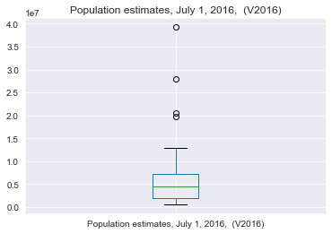

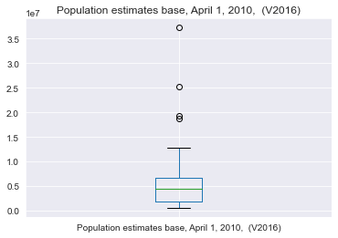

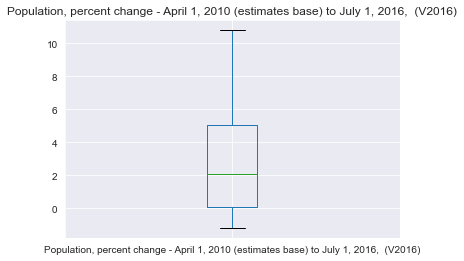

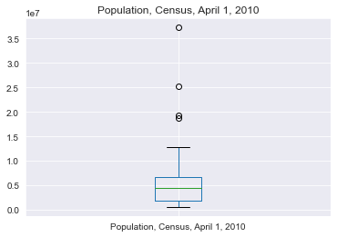

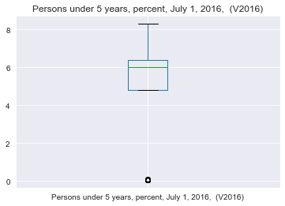

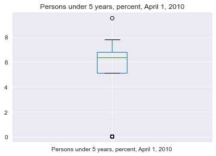

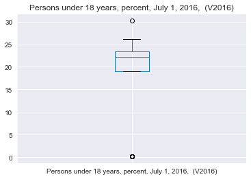

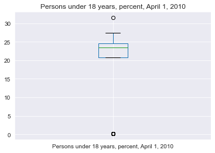

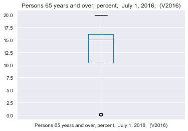

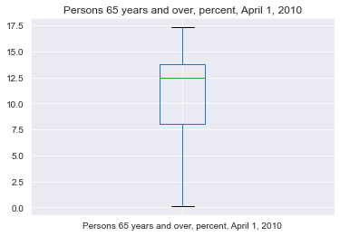

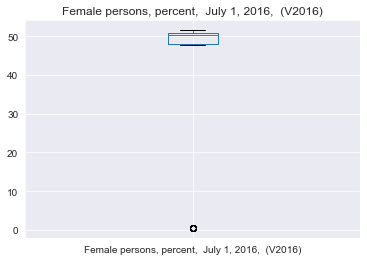

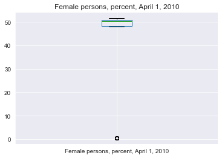

[52 more figures not shown]

```python
for i in df_census:
    df_census.boxplot(i)
    plt.title(i)
    plt.show()
```

A lot of the census data contains a large number of outliers

### Research Question 1 (What is the overall trend of gun purchases and background checks)

I extracted the neccesary data to plot the trend of gun purchases and background checks

I removed the data from 1998 and 2017 to only display the years with complete data

```python
df_gun.set_index('year', drop=False, inplace = True)
```

```python
todrop = ['1998', '2017']
```

```python
df_gun.drop(index=todrop, inplace = True)
df_gun.reset_index(drop=True, inplace=True)
```

```python
months = df_gun['month'].unique()
months = np.sort(months)
total_month= df_gun.groupby('month', as_index= False).sum()['totals']
total_month_sales = df_gun.groupby('month', as_index= False).sum()['estimated_total_sale']
```

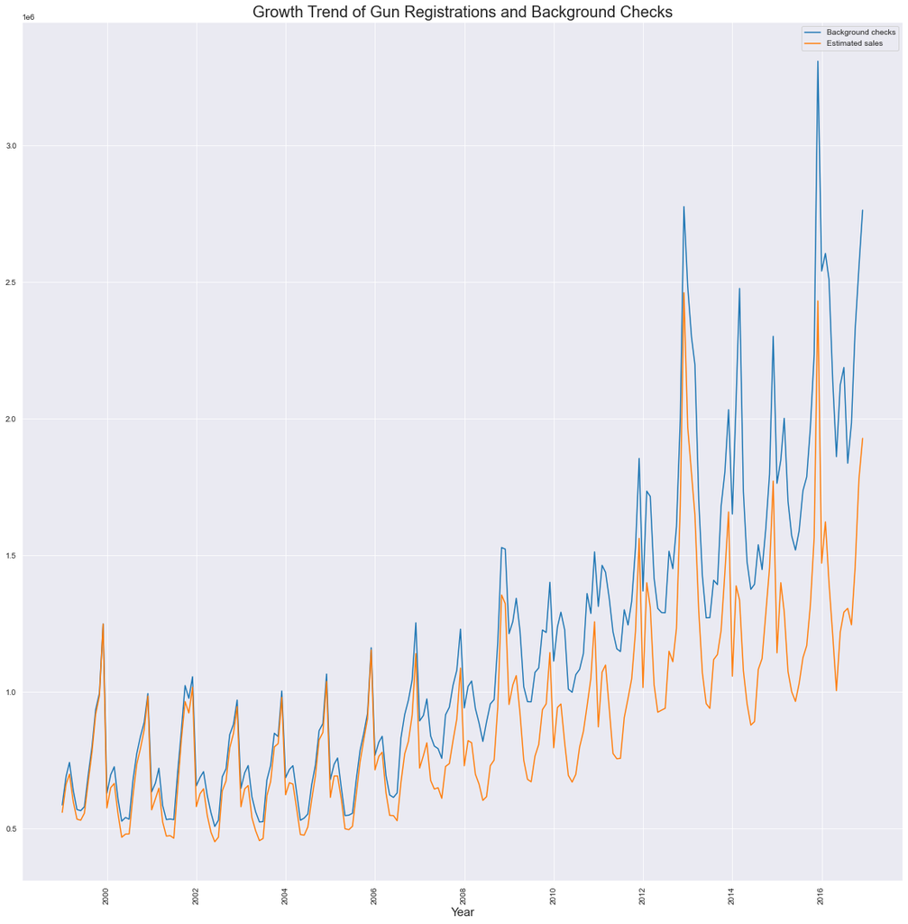

```python
plt.subplots(figsize=(20,20))
plt.plot(months, total_month, label = 'Background checks')
plt.plot(months, total_month_sales, label = 'Estimated sales')
plt.legend()
plt.xticks(rotation='vertical');
plt.xlabel('Year', fontdict={'fontsize': 15})
plt.title('Growth Trend of Gun Registrations and Background Checks', fontdict={'fontsize':20});
```

From the Above graph, we see an upward trend in both the purchase of firearms and number of background checks.

Both plots have 18 peaks corresponding to the 18 years plotted. This implies a seasonal trend.

I inspected the data further to determine what month in the year the sales peaked

```python
df_gun.groupby(df_gun.month.dt.month_name())['totals'].mean()
```

```
month
April        19902.366357
August       19637.724638
December     30456.099276
February     22894.695248
January      21198.191753
July         17552.752066
June         17248.499483
March        23620.162719
May          17545.731959
November     25266.931818
October      23131.262616
September    20419.081612
Name: totals, dtype: float64
```

```python
df_gun.groupby(df_gun.month.dt.month_name())['estimated_total_sale'].mean()
```

```
month
April        14747.482766
August       15309.997826
December     25986.190486
February     18133.096074
January      16017.369897
July         12828.069318
June         12630.517166
March        17682.745314
May          12841.528763
November     21170.593905
October      18487.192894
September    16325.371798
Name: estimated_total_sale, dtype: float64
```

On average, The estimated sales and background checks peak in December.